# Dimensionality Reduction and Feature Selection

Joe Kirika

15/07/2021

## Importing And Previewing The Data

### Importing the data

```r
# loading the data
df1 <- read.csv('http://bit.ly/CarreFourDataset')
```

### Previewing the data

```r
#checking the top rows of our dataset
print(head(df1))
```

```
##    Invoice.ID Branch Customer.type Gender           Product.line Unit.price
## 1 750-67-8428      A        Member Female      Health and beauty      74.69
## 2 226-31-3081      C        Normal Female Electronic accessories      15.28
## 3 631-41-3108      A        Normal   Male     Home and lifestyle      46.33
## 4 123-19-1176      A        Member   Male      Health and beauty      58.22
## 5 373-73-7910      A        Normal   Male      Sports and travel      86.31
## 6 699-14-3026      C        Normal   Male Electronic accessories      85.39
##   Quantity     Tax      Date  Time     Payment   cogs gross.margin.percentage
## 1        7 26.1415  1/5/2019 13:08     Ewallet 522.83                4.761905
## 2        5  3.8200  3/8/2019 10:29        Cash  76.40                4.761905
## 3        7 16.2155  3/3/2019 13:23 Credit card 324.31                4.761905
## 4        8 23.2880 1/27/2019 20:33     Ewallet 465.76                4.761905
## 5        7 30.2085  2/8/2019 10:37     Ewallet 604.17                4.761905
## 6        7 29.8865 3/25/2019 18:30     Ewallet 597.73                4.761905
##   gross.income Rating    Total
## 1      26.1415    9.1 548.9715
## 2       3.8200    9.6  80.2200
## 3      16.2155    7.4 340.5255
## 4      23.2880    8.4 489.0480
## 5      30.2085    5.3 634.3785
## 6      29.8865    4.1 627.6165
```

```r
#checking the bottom rows of our dataset
print(tail(df1))
```

```
##       Invoice.ID Branch Customer.type Gender           Product.line Unit.price
## 995  652-49-6720      C        Member Female Electronic accessories      60.95
## 996  233-67-5758      C        Normal   Male      Health and beauty      40.35
## 997  303-96-2227      B        Normal Female     Home and lifestyle      97.38
## 998  727-02-1313      A        Member   Male     Food and beverages      31.84
## 999  347-56-2442      A        Normal   Male     Home and lifestyle      65.82
## 1000 849-09-3807      A        Member Female    Fashion accessories      88.34
##      Quantity     Tax      Date  Time Payment   cogs gross.margin.percentage
## 995         1  3.0475 2/18/2019 11:40 Ewallet  60.95                4.761905
## 996         1  2.0175 1/29/2019 13:46 Ewallet  40.35                4.761905
## 997        10 48.6900  3/2/2019 17:16 Ewallet 973.80                4.761905
## 998         1  1.5920  2/9/2019 13:22    Cash  31.84                4.761905
## 999         1  3.2910 2/22/2019 15:33    Cash  65.82                4.761905
## 1000        7 30.9190 2/18/2019 13:28    Cash 618.38                4.761905
##      gross.income Rating     Total
## 995        3.0475    5.9   63.9975
## 996        2.0175    6.2   42.3675
## 997       48.6900    4.4 1022.4900
## 998        1.5920    7.7   33.4320
## 999        3.2910    4.1   69.1110
## 1000      30.9190    6.6  649.2990
```

```r
# checking the structure of the dataset
str(df1)
```

```
## 'data.frame':    1000 obs. of  16 variables:
##  $ Invoice.ID             : chr  "750-67-8428" "226-31-3081" "631-41-3108" "123-19-1176" ...
##  $ Branch                 : chr  "A" "C" "A" "A" ...
##  $ Customer.type          : chr  "Member" "Normal" "Normal" "Member" ...
##  $ Gender                 : chr  "Female" "Female" "Male" "Male" ...
##  $ Product.line           : chr  "Health and beauty" "Electronic accessories" "Home and lifestyle" "Health and beauty" ...
##  $ Unit.price             : num  74.7 15.3 46.3 58.2 86.3 ...
##  $ Quantity               : int  7 5 7 8 7 7 6 10 2 3 ...
##  $ Tax                    : num  26.14 3.82 16.22 23.29 30.21 ...
##  $ Date                   : chr  "1/5/2019" "3/8/2019" "3/3/2019" "1/27/2019" ...
##  $ Time                   : chr  "13:08" "10:29" "13:23" "20:33" ...
##  $ Payment                : chr  "Ewallet" "Cash" "Credit card" "Ewallet" ...
##  $ cogs                   : num  522.8 76.4 324.3 465.8 604.2 ...
##  $ gross.margin.percentage: num  4.76 4.76 4.76 4.76 4.76 ...
##  $ gross.income           : num  26.14 3.82 16.22 23.29 30.21 ...
##  $ Rating                 : num  9.1 9.6 7.4 8.4 5.3 4.1 5.8 8 7.2 5.9 ...
##  $ Total                  : num  549 80.2 340.5 489 634.4 ...
```

## Data Cleaning

```r
#check for nulls
colSums(is.na(df1))
```

```
##              Invoice.ID                  Branch           Customer.type
##                       0                       0                       0
##                  Gender            Product.line              Unit.price
##                       0                       0                       0
##                Quantity                     Tax                    Date
##                       0                       0                       0
##                    Time                 Payment                    cogs
##                       0                       0                       0
## gross.margin.percentage            gross.income                  Rating
##                       0                       0                       0
##                   Total
##                       0
```

```r
# Checking for duplicated data
dim(df1[duplicated(df1), ])
```

```
## [1]  0 16
```

> there were no null values or duplicated columns

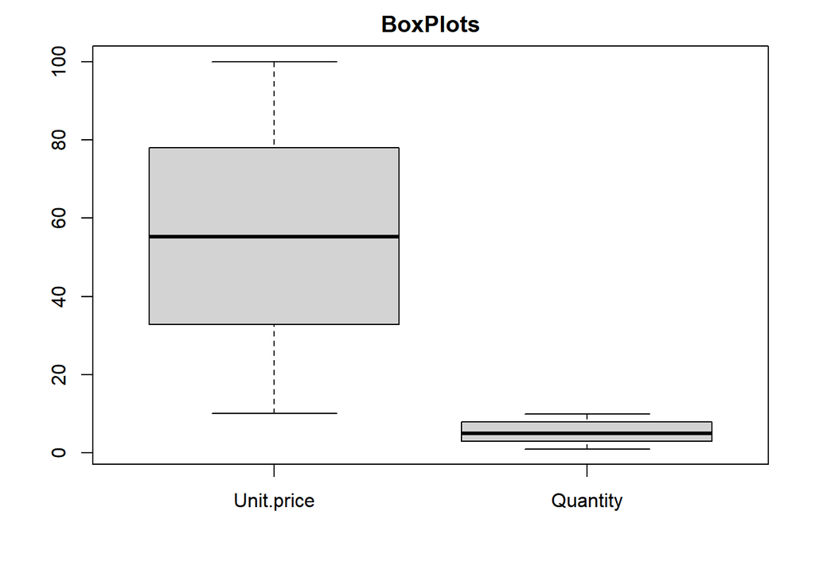

```r
# check for outliers/anomalies

# Finding all columns that are numerical/not strings & subsetting to new dataframe
df_num <- df1[, !sapply(df1, is.character)]

par(mfrow = c(1,1), mar = c(5,4,2,2))
boxplot(df_num[, c(1:2)], main='BoxPlots')
```

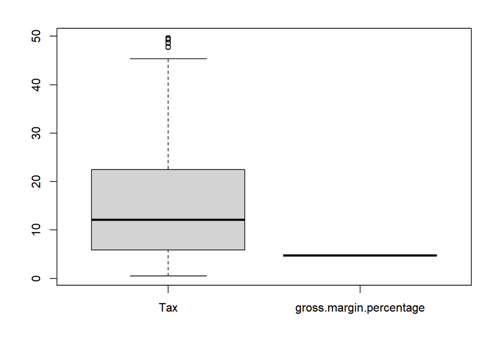

```r
boxplot(df_num[, c(3,5)])
```

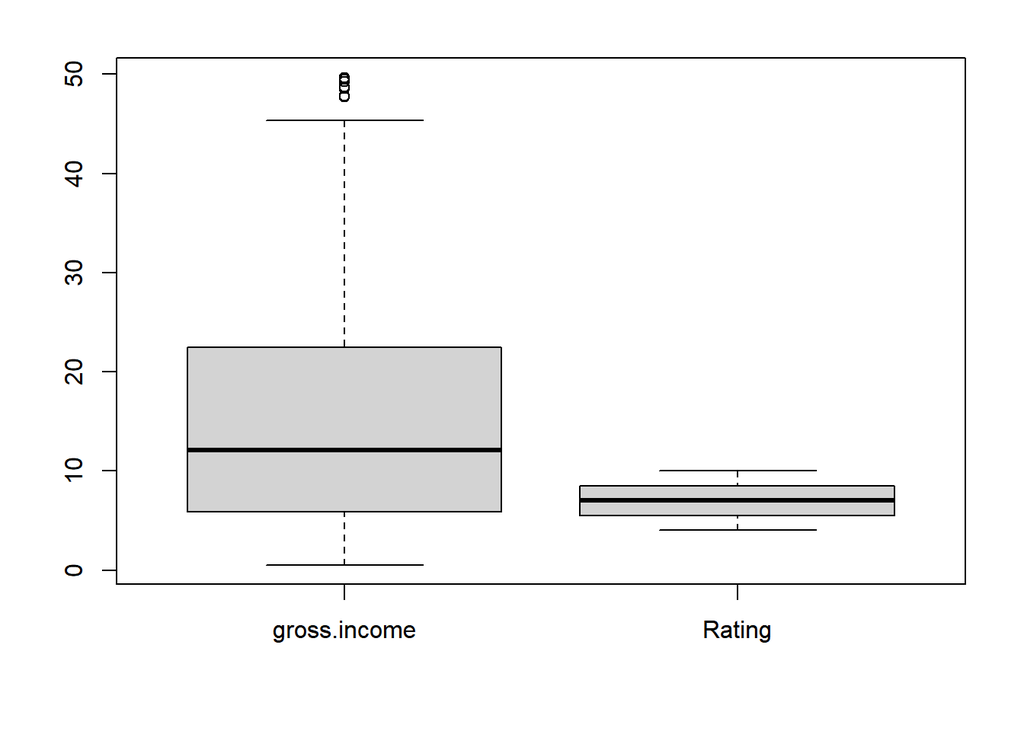

```r
boxplot(df_num[, c(6,7)])
```

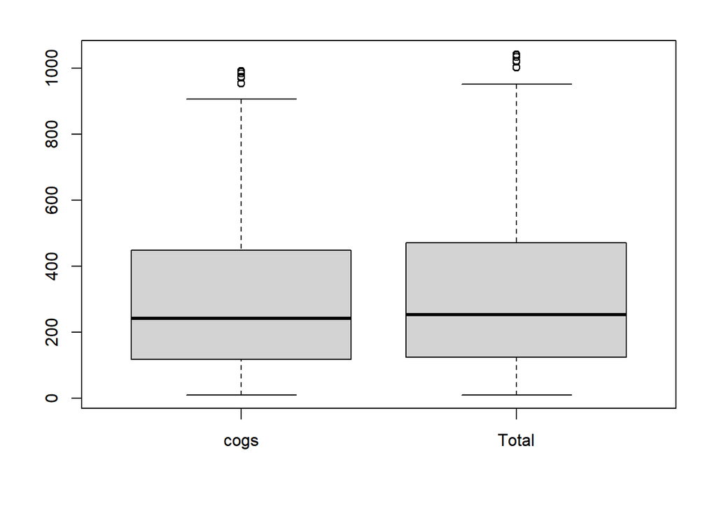

```r
boxplot(df_num[,c(4,8)])
```

> There are outliers in  
> * tax, * gross.income,  
> * cogs,  
> * Total.

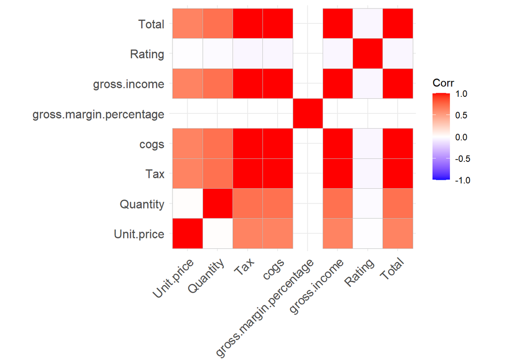

```r
# plotting a correlation matrix

library(ggcorrplot)
ggcorrplot(cor(df_num))
```

> from the correlation matrix we notice some highly positive correlated variables Tax, cogs and gross.income and as well as Total

# Principal Component Analysis

```r
# removing the column with no variance from the numerical columns
df_num <- df_num[,c(-5)]
```

```r
# We  pass df_num to the prcomp(). We also set two arguments, center and scale,
# to be TRUE then preview our object with summary

#
df.pca <- prcomp(df_num, center = TRUE, scale. = TRUE)
summary(df.pca)
```

```
## Importance of components:
##                           PC1    PC2    PC3     PC4       PC5       PC6
## Standard deviation     2.2185 1.0002 0.9939 0.30001 2.981e-16 1.493e-16
## Proportion of Variance 0.7031 0.1429 0.1411 0.01286 0.000e+00 0.000e+00
## Cumulative Proportion  0.7031 0.8460 0.9871 1.00000 1.000e+00 1.000e+00
##                              PC7
## Standard deviation     9.831e-17
## Proportion of Variance 0.000e+00
## Cumulative Proportion  1.000e+00
```

> PC1, PC2 and PC3 explains ~ 98.71% of the proportion of variance in the data with PC1 = 70.31% PC2=14.29% and PC3 = 14.11%

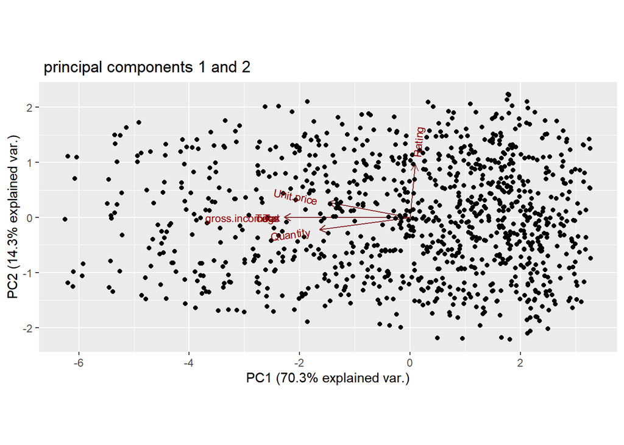

```r
# Then Loading our ggbiplot library to visualize the pcas
#
library(ggbiplot)
ggbiplot(df.pca, obs.scale = 1, var.scale = 2)+ labs(title=" principal components 1 and 2")
```

> we see that unit.price, gloss.income and quantity contribute to PC1 with higher values in those variables moving the samples to the left on the plot and the Rating variable contribute to PC2

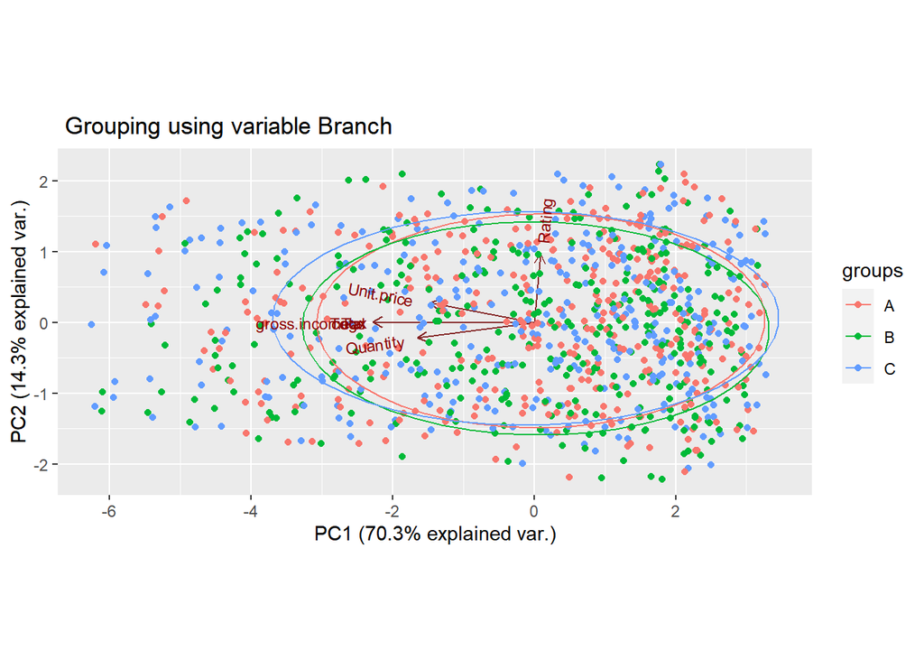

```r
#
ggbiplot(df.pca,ellipse=TRUE,groups=df1$Branch, obs.scale = 1, var.scale = 2) + labs(title=" Grouping using variable Branch")
```

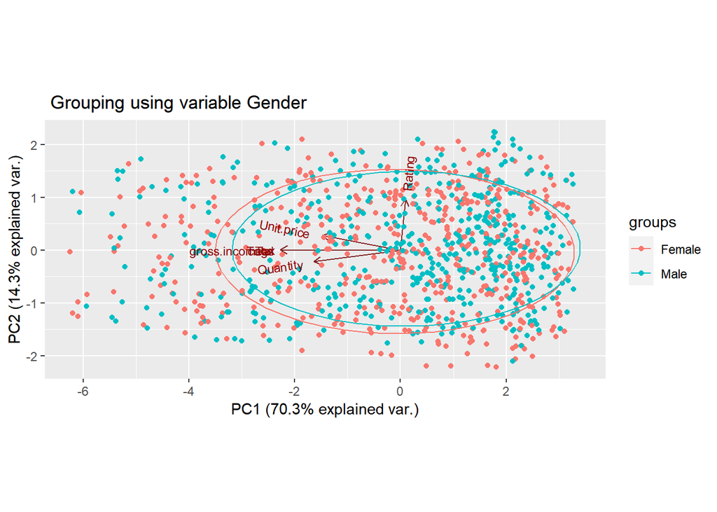

```r
#
ggbiplot(df.pca, ellipse=TRUE, groups = df1$Gender, obs.scale = 1, var.scale = 2)+ labs(title=" Grouping using variable Gender")
```

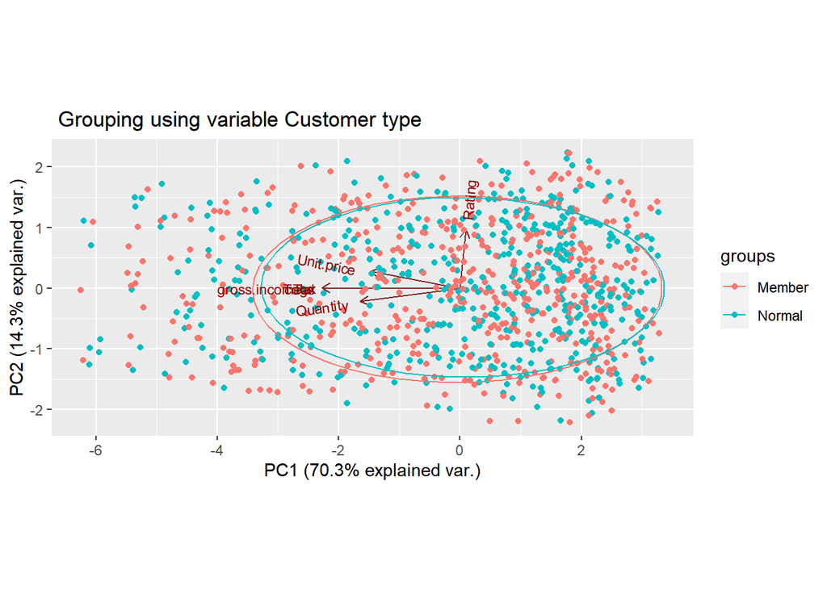

```r
ggbiplot(df.pca, ellipse=TRUE, groups = df1$Customer.type, obs.scale = 1, var.scale = 2)+ labs(title=" Grouping using variable Customer type")
```

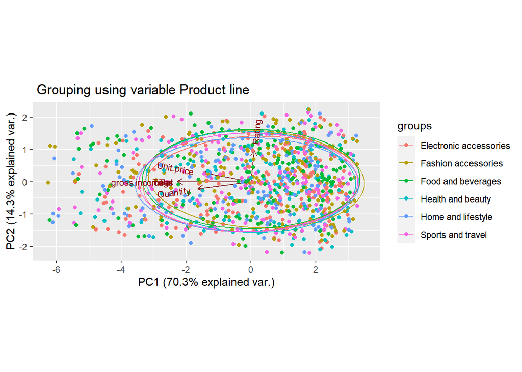

```r
ggbiplot(df.pca, ellipse=TRUE, groups = df1$Product.line, obs.scale = 1, var.scale = 2)+ labs(title=" Grouping using variable Product line")
```

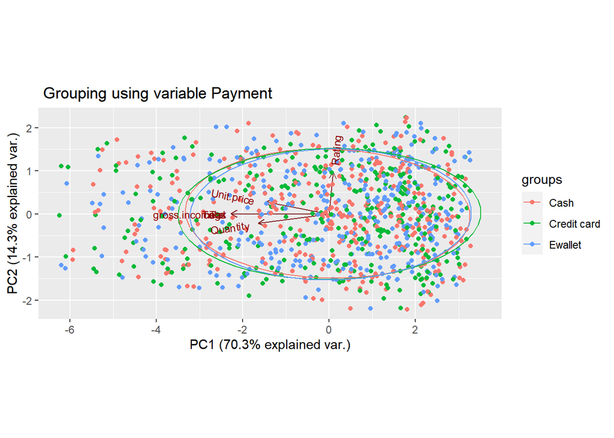

```r
ggbiplot(df.pca, ellipse=TRUE, groups = df1$Payment, obs.scale = 1, var.scale = 2)+ labs(title=" Grouping using variable Payment")
```

> as observed, trying to cluster using categorical variables does not seem to accrue enough information since the clusters overlap

## Feature Selection

#### using correlationmatrix

```r
# importing the libraries
library(caret)
```

```r
library(corrplot)
# computing the correlation of the numerical column
correlationMatrix <- cor(df_num)
```

```r
# filtering the highly corrlated variables at 0.75
highlyCorrelated <- findCorrelation(correlationMatrix, cutoff=0.75)
```

```r
# getting the Highly correlated attributes
# ---
#
highlyCorrelated
```

```
## [1] 4 7 3
```

```r
# getting the names
names(df_num[,highlyCorrelated])
```

```
## [1] "cogs"  "Total" "Tax"
```

> the above variables are highly correlated

#### Using Wrapper Methods

```r
# importing some libraries
library(clustvarsel)
library(mclust)
```

```r
# Sequential forward greedy search (default)
clustvarsel(df_num)
```

```
## ------------------------------------------------------
## Variable selection for Gaussian model-based clustering
## Stepwise (forward/backward) greedy search
## ------------------------------------------------------
##
##  Variable proposed Type of step   BICclust Model G   BICdiff Decision
##           Quantity          Add  -4308.761     E 9  687.4466 Accepted
##               cogs          Add -16306.851   VEV 9 1083.0132 Accepted
##         Unit.price          Add -21393.079   EVV 7 2812.3733 Accepted
##         Unit.price       Remove -16306.851   VEV 9 2812.3733 Rejected
##             Rating          Add -25510.859   EVV 7 -184.0917 Rejected
##         Unit.price       Remove -16306.851   VEV 9 2812.3733 Rejected
##
## Selected subset: Quantity, cogs, Unit.price
```

> from the wrapper methods suggests Quantity, cogs, Unit.price as the optimal subset of variables for further analysis

### Recommendations

> PC1, PC2 and PC3 explains ~ 98.71% of the proportion of variance in the data with PC1 = 70.31% PC2=14.29% and PC3 = 14.11%  
> from the wrapper methods suggests Quantity, cogs, Unit.price as the optimal subset of variables for further analysis trying to cluster using categorical variables does not seem to accrue enough information since the clusters overlap  
> “cogs” “Total” “Tax” are highly correlated